# question_3

```python
import numpy as np
import pandas as pd
import seaborn as sns
import matplotlib.pyplot as plt

from sklearn.ensemble import GradientBoostingClassifier
from sklearn.ensemble import RandomForestClassifier
from sklearn.linear_model import LogisticRegression
from sklearn.model_selection import cross_val_score, GridSearchCV, train_test_split
from sklearn.metrics import roc_curve, auc, confusion_matrix, plot_confusion_matrix, f1_score
from sklearn.pipeline import Pipeline
from sklearn.pipeline import make_pipeline
from xgboost import XGBClassifier
```

```python
plt.rcParams["figure.figsize"] = (40, 20)
plt.rcParams["font.size"] = 32

np.random.seed(42) # For reproducibility
```

```python
df = pd.read_pickle("../data/df_for_prediction.pkl")
```

#### Looking at feature correlations.

If there are features too correlated with each other or with the target I will have to remove them, because they could introduce overfitting.

```python
cor = df.corr()
```

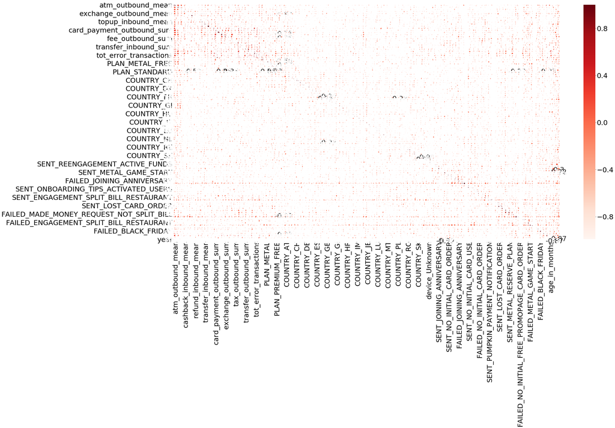

```python
sns.heatmap(cor, annot=True, cmap=plt.cm.Reds)
plt.show()
```

The above correlation map is too cluttered, I will manually check if there are elements higly correlated with each other.

```python
correlated_features = []
theshold = 0.6
for col_name, row in cor.iterrows():
    for other in row[row > theshold].index:
        if other != col_name:
            if (other, col_name, row[other]) not in correlated_features:
                correlated_features.append((col_name, other, row[other]))
```

```python
correlated_features
```

```
[('exchange_outbound_mean', 'topup_inbound_mean', 0.7739258625704226),
 ('exchange_outbound_mean', 'transfer_outbound_mean', 0.8025500522332973),
 ('tax_outbound_mean', 'tax_outbound_sum', 0.8062186223272994),
 ('card_payment_outbound_sum', 'tot_merchant_city', 0.7113655454443606),
 ('card_payment_outbound_sum', 'avg_online_transactions', 0.9190159492315984),
 ('card_payment_outbound_sum', 'transaction_count', 0.7980058736563131),
 ('transfer_outbound_sum', 'transaction_count', 0.6591683897672289),
 ('tot_merchant_city', 'avg_online_transactions', 0.6504315636547462),
 ('avg_online_transactions', 'transaction_count', 0.7226709939248955),
 ('SENT_NO_INITIAL_CARD_ORDER',
  'FAILED_NO_INITIAL_CARD_ORDER',
  0.8054457506955407),
 ('FAILED_METAL_RESERVE_PLAN', 'SENT_METAL_RESERVE_PLAN', 0.7530789684982674)]
```

From above I can definelty see that there are few higly correlated features, hence to avoid overfitting I will delete some.

NOTE: I have actually run this correlation step quite a few time before getting to this set of features. Initally I added many more features, and after analysing the correlation I have decided to go back and eliminate few. This has been an iterative process which I have omitted for clarity.

```python
df = df.drop(columns=['exchange_outbound_mean', 'card_payment_outbound_sum', 'transaction_count','FAILED_NO_INITIAL_CARD_ORDER', 'FAILED_METAL_RESERVE_PLAN'])
```

#### Looking at proportion between classes

```python
tmp = df.target.reset_index().groupby("target").size()
print(tmp.div(tmp.sum()))
del tmp
```

```
target
churned        0.103753
not churned    0.896247
dtype: float64
```

The data is a bit unbalanced, but it is not too extreme, but would be better to do some over and under sampling.

Random Undersampling and Oversampling

```python
# Divide by class
df_class_0 = df[df['target'] == 'not churned']
df_class_1 = df[df['target'] == 'churned']

df_class_0_under = df_class_0.sample(int(len(df_class_0) * 0.6)) # Reduce by 40%
resamples = df_class_1.sample(int(len(df_class_1)*0.5)) # Sample extra 50%
df = pd.concat([df_class_0_under, df_class_1, resamples], axis=0)
print('Random under-sampling:')
print(df.target.value_counts())
```

```
Random under-sampling:
not churned    37167
churned        10756
Name: target, dtype: int64
```

```python
X = df.loc[:, df.columns != 'target']
y = df.loc[:, 'target']
```

## Building models

I am going to try 3 different models: `RandomForestClassifier`, `LogisticRegression` and `XGBClassifier`. The first two are really for benchmark. They can give a good estimate of what can be achieved in terms of performances with little or no parameter tuning. I will then compare `XGBClassifier`, a more advanced classifier with the default parameters to see how it compares. I will later do some grid search to see if I can further improve its performances.

```python
model_rf = RandomForestClassifier(min_samples_split=5, n_estimators=300)
model_lr = LogisticRegression(solver='liblinear')
model_xgb = XGBClassifier(objective="binary:logistic")
```

```python
random_forest_scores = cross_val_score(model_rf, X, y, cv=5)
random_forest_scores
```

```
array([0.81460616, 0.86311946, 0.88742827, 0.91005843, 0.92831803])
```

```python
logistic_reg_scores = cross_val_score(model_lr, X, y, cv=5)
logistic_reg_scores
```

```
array([0.7219614 , 0.78894105, 0.81606677, 0.82585559, 0.80269199])
```

```python
xgb_scores = cross_val_score(model_xgb, X, y, cv=5)
xgb_scores
```

```
array([0.72822118, 0.82910798, 0.91392801, 0.86999165, 0.83420284])
```

```python
scores_df = pd.DataFrame({"Random forest scores":random_forest_scores, "Logistic regression scores":logistic_reg_scores, "XGBoost scroes":xgb_scores})
```

```
Random forest scores          0.880706
Logistic regression scores    0.791103
XGBoost scroes                0.835090
dtype: float64
```

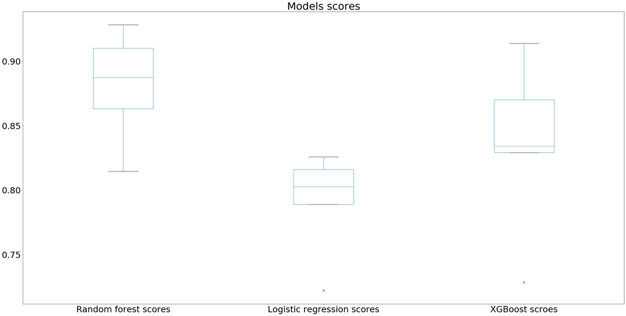

```python
ax = scores_df.plot(kind='box')
_=ax.set_title("Models scores")
print(scores_df.mean())
```

#### Parameter tuning

It is clear from the above chart that XGBoost could do with some parameter tuning. Let's try do some grid search.

NOTE: the cell below will take a very long time!

```python
# params = {"learning_rate"    : [0.05, 0.10, 0.15, 0.20, 0.25, 0.30 ] ,
#           "max_depth"        : [ 3, 4, 5, 6, 8, 10, 12, 15],
#           "min_child_weight" : [ 1, 3, 5, 7 ],
#           "gamma"            : [ 0.0, 0.1, 0.2 , 0.3, 0.4 ],
#           "colsample_bytree" : [ 0.3, 0.4, 0.5 , 0.7 ] }

# clf = GridSearchCV(model_xgb, params, refit='True', cv=5, n_jobs=7)
# clf.fit(X, y)
# print("Scores: {}".format(sorted(clf.cv_results_.keys())))
# print("Best scores: " + str(clf.best_score_))
# print("Best params: " + str(clf.best_params_))
```

Unfortuantely this step took too long and decided to omit it. But would have been interesting to see what could be achieved.

#### Looking at Feature importance

Let's look at random forest feature importance

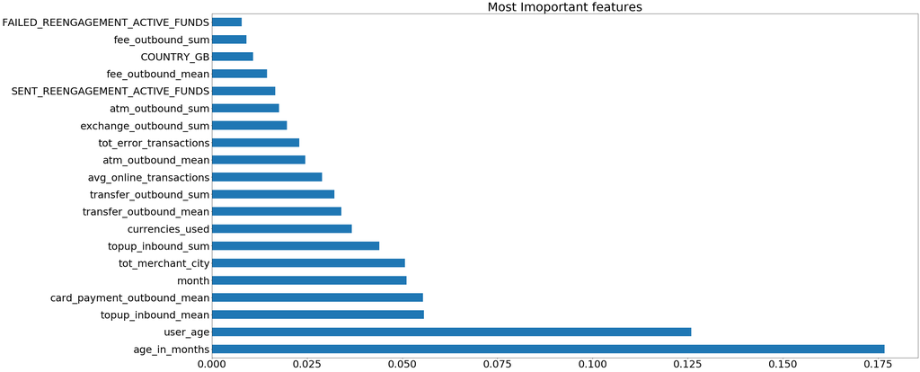

```python
model_rf.fit(X, y)
feat_importances = pd.Series(model_rf.feature_importances_, index=X.columns)
ax=feat_importances.nlargest(20).plot(kind='barh')
_=ax.set_title("Most Imoportant features")
```

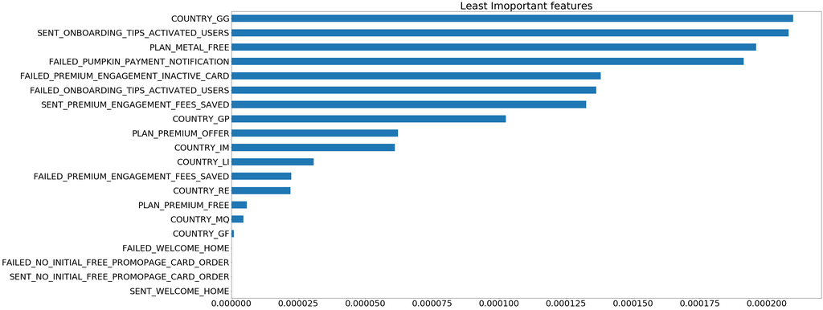

```python
ax=feat_importances.nsmallest(20).plot(kind='barh')
_=ax.set_title("Least Imoportant features")
```

It looks like that there are some features that really do not need to be include, as the could just introduce noise. Let's try remove features that contribute less than `0.01` and let's see if performances improve.

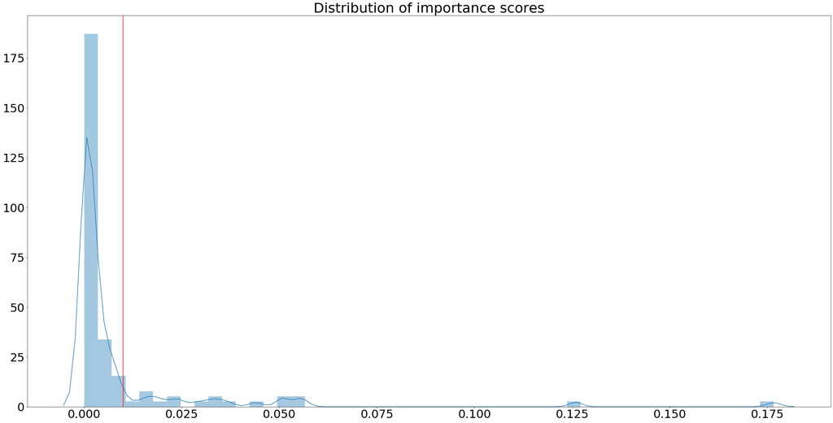

```python
ax=sns.distplot(feat_importances)
ax.axvline(0.01, c='r')
_=ax.set_title("Distribution of importance scores")
```

Seems that a treshold at `0.01` will cut off quite a lot of unimportant features

```python
df_selected = df.drop(columns=feat_importances[feat_importances < 0.01].index.values)
```

```python
X = df_selected.loc[:, df_selected.columns != 'target']
y = df_selected.loc[:, 'target']
```

```python
random_forest_scores = cross_val_score(model_rf, X, y, cv=5)
print("Random forest scores: {}".format(random_forest_scores))

logistic_reg_scores = cross_val_score(model_lr, X, y, cv=5)
print("Logistic reg scores: {}".format(logistic_reg_scores))

xgb_scores = cross_val_score(model_xgb, X, y, cv=5)
print("XGBoost scores: {}".format(xgb_scores))
```

```
Random forest scores: [0.8238915  0.86103286 0.86280647 0.90411102 0.92790067]
Logistic reg scores: [0.71653625 0.78925404 0.80031299 0.81771703 0.7870409 ]
XGBoost scores: [0.72686489 0.82900365 0.83432447 0.86915693 0.83201169]
```

```python
selection_scores_df = pd.DataFrame({"Random forest scores":random_forest_scores, "Logistic regression scores":logistic_reg_scores, "XGBoost scroes":xgb_scores})
```

```
Random forest scores                           0.880706
Logistic regression scores                     0.791103
XGBoost scroes                                 0.835090
Random forest scores feature selected          0.875949
Logistic regression scores feature selected    0.782172
XGBoost scroes feature selected                0.818272
dtype: float64
```

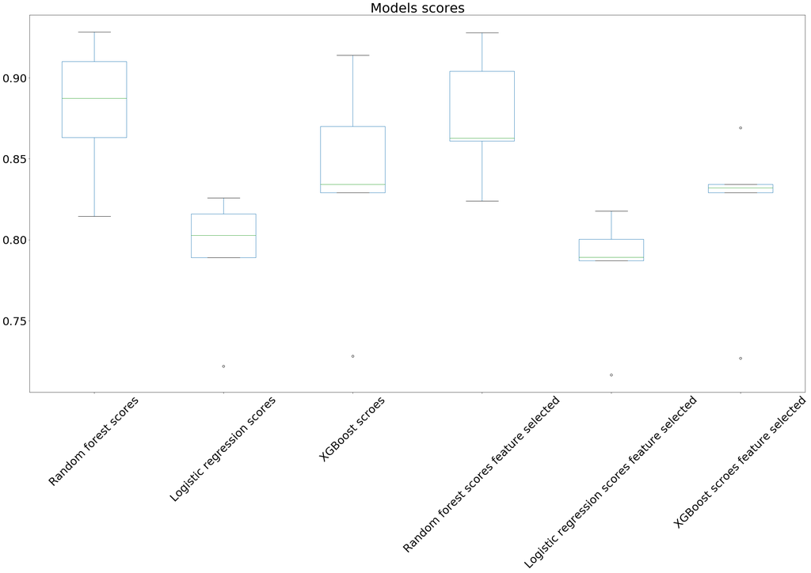

```python
tmp = pd.merge(scores_df, selection_scores_df, right_index=True, left_index=True, suffixes=['', ' feature selected'])
ax = tmp.plot(kind='box')
plt.xticks(rotation=45)
_=ax.set_title("Models scores")
print(tmp.mean())
del tmp
```

It is difficult to draw conclusions but seems that feature selection didn't helped much this time. I could probably try few more combinations but time is limited.

#### Error analysis

Let's now look at the type of errors that the best classifier produce.

```python
# shuffle and split training and test sets
X_train, X_test, y_train, y_test = train_test_split(X, y, test_size=.15, random_state=3)

y_score = model_rf.fit(X_train, y_train).predict_proba(X_test)[:, 0]
y_predicted = model_rf.fit(X_train, y_train).predict(X_test)
print("F1 score: {}".format(f1_score(y_test, y_predicted, average='macro')))

# Compute ROC curve and ROC area for each class
fpr, tpr, _ = roc_curve(y_test, y_score, pos_label='churned')
roc_auc = auc(fpr, tpr)
```

```
F1 score: 0.830427545120028
```

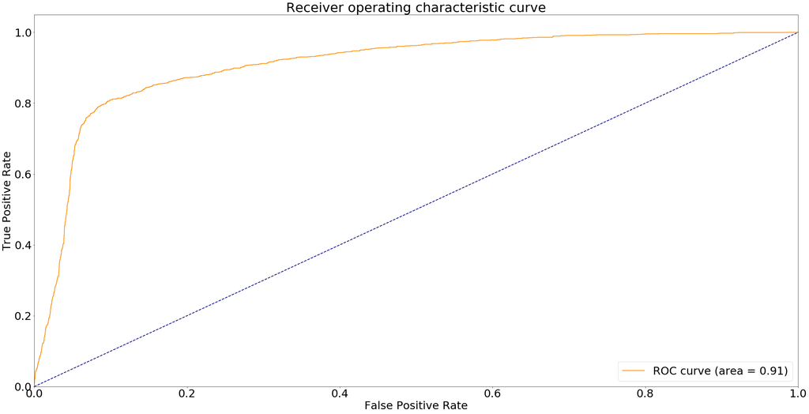

```python
lw = 2
plt.plot(fpr, tpr, color='darkorange',
         lw=lw, label='ROC curve (area = %0.2f)' % roc_auc)
plt.plot([0, 1], [0, 1], color='navy', lw=lw, linestyle='--')
plt.xlim([0.0, 1.0])
plt.ylim([0.0, 1.05])
plt.xlabel('False Positive Rate')
plt.ylabel('True Positive Rate')
plt.title('Receiver operating characteristic curve')
plt.legend(loc="lower right")
plt.show()
```

```python
y_test.reset_index().groupby("target").size()
```

```
target
churned        1565
not churned    5624
dtype: int64
```

```
[[1083  482]
 [ 316 5308]]
```

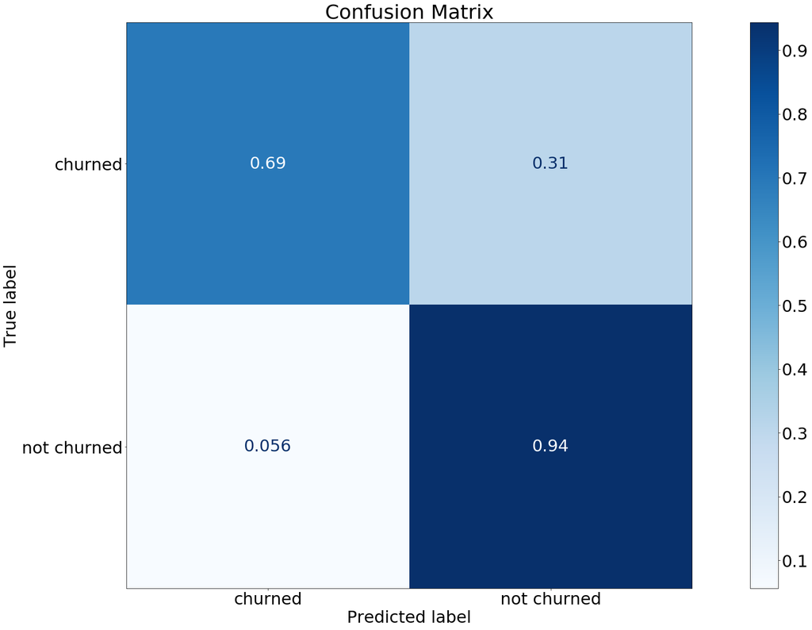

```python
cm = confusion_matrix(y_test, y_predicted)
print(cm)
disp = plot_confusion_matrix(model_rf, X_test, y_test,
                                 cmap=plt.cm.Blues,
                                 normalize='true')
disp.ax_.set_title("Confusion Matrix")


plt.show()
```

The classifier is not bad overall. But it is clearly better at understanding if a user won't churn rather than if it will. This is usually to be expected unfortunately in these sort of problems.